# Final Project (PSTAT 231)

Modjtaba Shokrian Zini, Glen Frost

3/20/2019

# 1- Background

```
What makes voter behavior prediction (and thus election forecasting) a hard problem?
```

It is unknown precisely how a voter determines their personal vote. Humans can make irrational decisions and vote based on emotions, which can be hard to predict. Geopolitical events are highly unpredictable and the news media can frame the events in different ways to influence voters. The concept of an October surprise captures this idea: “a news event deliberately created or timed or sometimes occurring spontaneously to influence the outcome of an election” (source: Wikipedia)

```
What was unique to Nate Silverâs approach in 2012 that allowed him to achieve good predictions?
```

Silver constructs a model that uses high quality polls from bigger state races such as Florida to augment scarcity of polls in smaller races such as Montana. Data from previous elections allows him to weigh the information appropriately. The polls were more reliable during 2012 and didn’t change much over time, which makes time series models (a classical tool in voting prediction) more effective.

```
What went wrong in 2016? What do you think should be done to make future predictions better?
```

One of the biggest changes in 2016 is the rise of social media. Facebook is reaching its peak and implements a news portal to provide news to users without leaving the site, as well as algorithms to filter out misleading content. The filter relies on users to report content and train the algorithm. Combined together these Facebook features create a “filter bubble” where content the user disagrees with are suppressed.

Another factor is unreliability of polls. There is a large proportion of undecided voters in this election due to the unpopularity of both candidates. Nate Silver in his tweets on election day admits that this is causing prediction errors. Also voters are reluctant to admit support for Trump, leading to polls skewed toward Clinton.

Our analysis below shows that Trump wins by the narrowest of margins: less than 100,000 votes in a few counties. With many voters remaining exactly on the fence on election day, this results in highly unstable predictions. In order to make better predictions in the future we would want to obtain more data.

# 2- Data Wrangling

4. Before we begin we must clean the data. Alaska has a fips value of 2000, so the rows where `fips=2000` are indeed state-level summary of election results. However, the state-level summary rows of Alaska are already available when we read the data, so it makes no sense to have duplicate records. We remove the counties with `fips=2000` from `election.raw`. The dimension of election.raw is `18345 x 5`.
5. We build dataframes `election_federal` and `election_state` which contains summary information at the federal and state levels.
6. We have the following candidates in the election:

| Candidates |
| --- |
| None of these candidates |
| Alyson Kennedy |
| Bradford Lyttle |
| Chris Keniston |
| Dan Vacek |
| Darrell Castle |
| Donald Trump |
| Emidio Soltysik |
| Evan McMullin |
| Frank Atwood |
| Gary Johnson |
| Gloria La Riva |
| Hillary Clinton |
| Jerry White |
| Jill Stein |
| Jim Hedges |
| Joseph Maldonado |
| Kyle Kopitke |
| Laurence Kotlikoff |
| Lynn Kahn |
| Michael Maturen |
| Mike Smith |
| Monica Moorehead |
| Peter Skewes |
| Princess Jacob |
| Richard Duncan |
| Rocky De La Fuente |
| Rocky Giordani |
| Rod Silva |
| Ryan Scott |
| Scott Copeland |
| Tom Hoefling |

There are 32 candidates, but the candidate " None of these candidates" is not a named candidate. Hence there are 31 named candidates. We plot the vote count per candidates with a log scale:

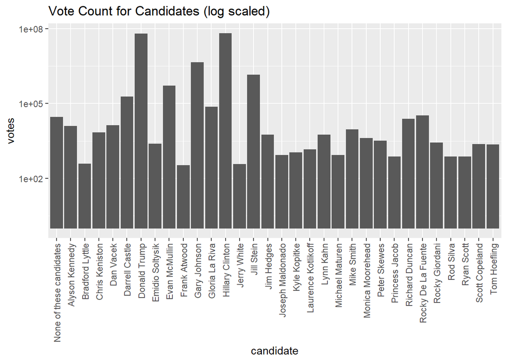

7. We create new variables `county_winner` and `state_winner` by taking the candidate with the highest proportion of votes.

**Datasets to be used for future**

We also build dataframes storing the county and state results for three of the main four candidates Hillary Clinton, Donald Trump, Gary Johnson (and Jill Stein), in order to predict votes in the further exploration section. We only focus on three of the four main candidates (excluding Jill Stein), as they determine the votes of the last one pretty well.

# 3- Visualization

Visualizing the state map:

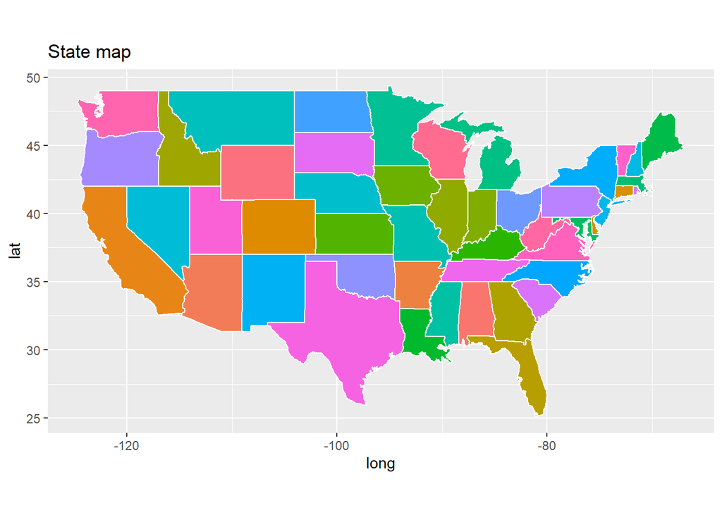

8. Visualizing the county map:

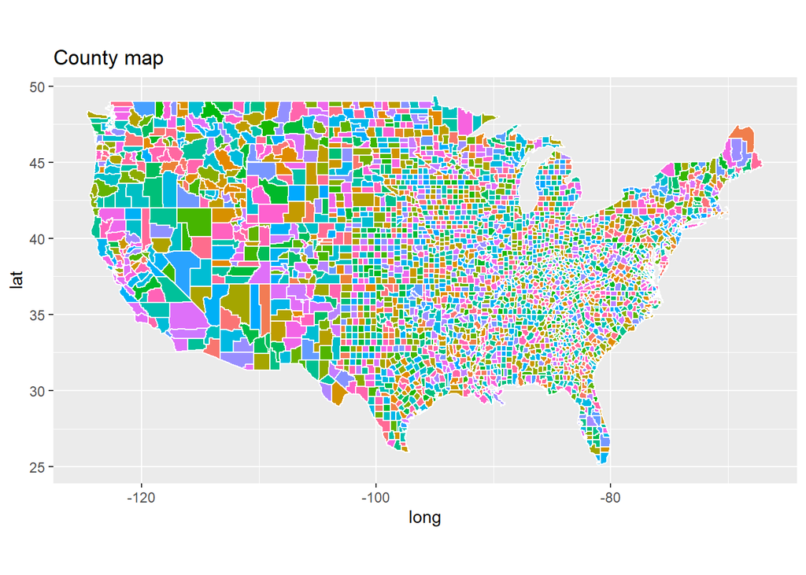

9. Coloring the map for the winning candidate:

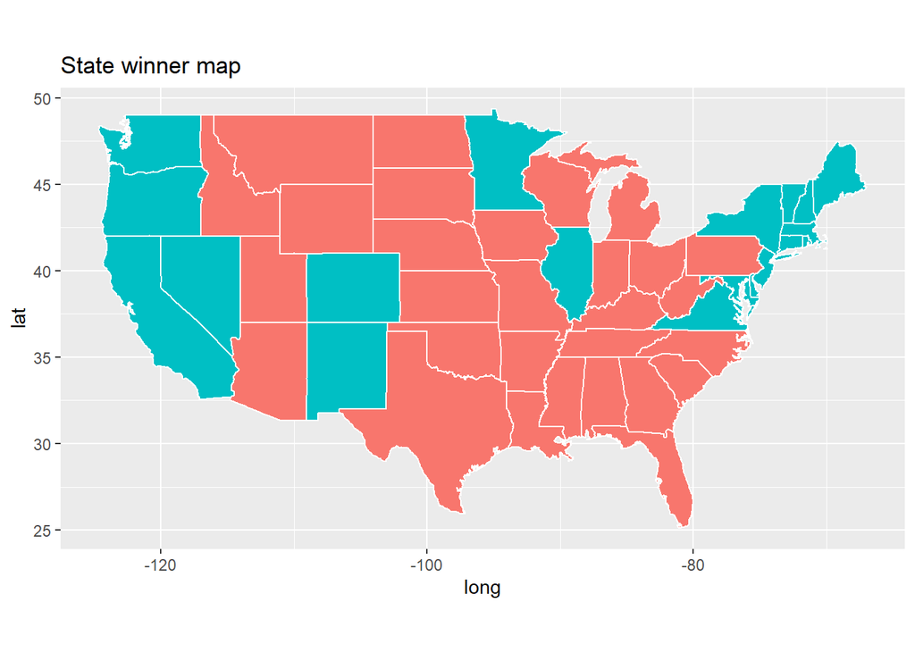

10. Visualizing the county map according to the winner:

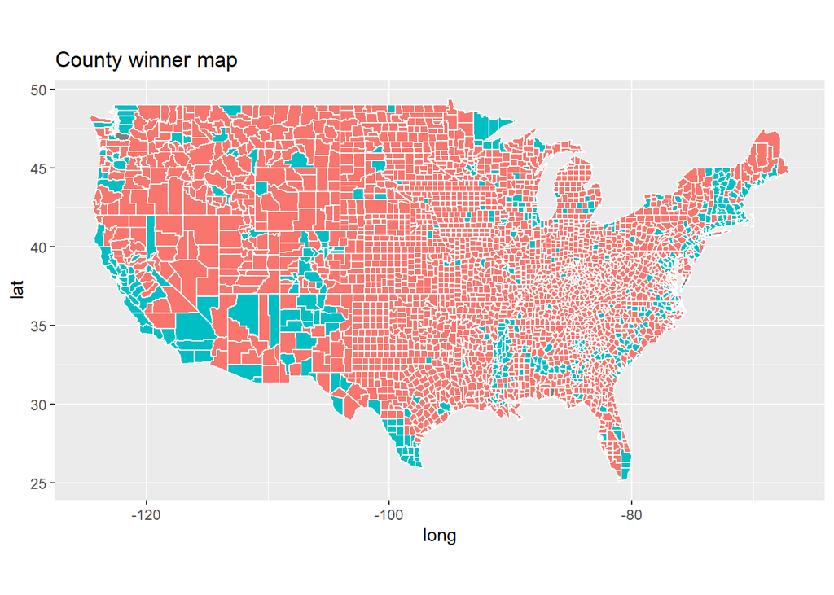

11. Answered after 13).
12. We build `census.del` (see .Rmd file). We also delete the `Women` column as it is determined be `Man`.

We also build `census.subct` and `census.ct` as instructed and we print the first few rows of `census.ct`.

| State | County | Men | White | Citizen | Income | IncomeErr | IncomePerCap | IncomePerCapErr | Poverty | ChildPoverty | Professional | Service | Office | Production | Drive | Carpool | Transit | OtherTransp | WorkAtHome | MeanCommute | Employed | PrivateWork | SelfEmployed | FamilyWork | Unemployment | Minority | CountyTotal |
| --- | --- | --- | --- | --- | --- | --- | --- | --- | --- | --- | --- | --- | --- | --- | --- | --- | --- | --- | --- | --- | --- | --- | --- | --- | --- | --- | --- |
| Alabama | Autauga | 0.4843266 | 75.78823 | 0.7374912 | 51696.29 | 7771.009 | 24974.50 | 3433.674 | 12.91231 | 18.70758 | 32.79097 | 17.17044 | 24.28243 | 17.15713 | 87.50624 | 8.781235 | 0.0952590 | 1.3059687 | 1.8356531 | 26.50016 | 0.4343637 | 73.73649 | 5.433254 | 0.0000000 | 7.733726 | 22.53687 | 55221 |
| Alabama | Baldwin | 0.4884866 | 83.10262 | 0.7569406 | 51074.36 | 8745.050 | 27316.84 | 3803.718 | 13.42423 | 19.48431 | 32.72994 | 17.95092 | 27.10439 | 11.32186 | 84.59861 | 8.959078 | 0.1266209 | 1.4438000 | 3.8504774 | 26.32218 | 0.4405113 | 81.28266 | 5.909353 | 0.3633269 | 7.589820 | 15.21426 | 195121 |
| Alabama | Barbour | 0.5382816 | 46.23159 | 0.7691222 | 32959.30 | 6031.065 | 16824.22 | 2430.189 | 26.50563 | 43.55962 | 26.12404 | 16.46343 | 23.27878 | 23.31741 | 83.33021 | 11.056609 | 0.4954032 | 1.6217251 | 1.5019456 | 24.51828 | 0.3192113 | 71.59426 | 7.149837 | 0.0897742 | 17.525557 | 51.94382 | 26932 |
| Alabama | Bibb | 0.5341090 | 74.49989 | 0.7739781 | 38886.63 | 5662.358 | 18430.99 | 3073.599 | 16.60375 | 27.19708 | 21.59010 | 17.95545 | 17.46731 | 23.74415 | 83.43488 | 13.153641 | 0.5031366 | 1.5620952 | 0.7314679 | 28.71439 | 0.3669262 | 76.74385 | 6.637936 | 0.3941515 | 8.163104 | 24.16597 | 22604 |
| Alabama | Blount | 0.4940565 | 87.85385 | 0.7337550 | 46237.97 | 8695.786 | 20532.27 | 2052.055 | 16.72152 | 26.85738 | 28.52930 | 13.94252 | 23.83692 | 20.10413 | 84.85031 | 11.279222 | 0.3626321 | 0.4199411 | 2.2654133 | 34.84489 | 0.3844914 | 81.82671 | 4.228716 | 0.3564928 | 7.699640 | 10.59474 | 57710 |
| Alabama | Bullock | 0.5300618 | 22.19918 | 0.7545420 | 33292.69 | 9000.345 | 17579.57 | 3110.645 | 24.50260 | 37.29116 | 19.55253 | 14.92420 | 20.17051 | 25.73547 | 74.77277 | 14.839127 | 0.7732160 | 1.8238247 | 3.0998783 | 28.63106 | 0.3619592 | 79.09065 | 5.273684 | 0.0000000 | 17.890026 | 76.53587 | 10678 |

13. I was in California, Santa Barbara County. To compare the county against the state, we need to summarise census and build a `census.s` dataframe similar to `census.ct`.

| State | Men | White | Citizen | Income | IncomeErr | IncomePerCap | IncomePerCapErr | Poverty | ChildPoverty | Professional | Service | Office | Production | Drive | Carpool | Transit | OtherTransp | WorkAtHome | MeanCommute | Employed | PrivateWork | SelfEmployed | FamilyWork | Unemployment | Minority | StateTotal |
| --- | --- | --- | --- | --- | --- | --- | --- | --- | --- | --- | --- | --- | --- | --- | --- | --- | --- | --- | --- | --- | --- | --- | --- | --- | --- | --- |
| Alabama | 0.4846602 | 66.32337 | 0.7492430 | 47154.21 | 7737.731 | 24125.80 | 3338.892 | 18.95652 | 27.00069 | 32.01863 | 17.21995 | 23.98557 | 16.651936 | 85.11536 | 9.421558 | 0.4779164 | 1.069649 | 2.713573 | 24.49893 | 0.4189551 | 78.19577 | 5.269010 | 0.1908982 | 9.670126 | 32.03480 | 4821879 |
| Alaska | 0.5224436 | 62.25894 | 0.7133115 | 74675.58 | 9320.227 | 33120.23 | 4003.780 | 10.19457 | 13.52082 | 35.81542 | 17.84260 | 22.94763 | 10.788934 | 66.84995 | 12.513605 | 1.5886901 | 6.342874 | 4.494435 | 19.24410 | 0.4769286 | 66.79517 | 6.217542 | 0.1933571 | 8.641277 | 30.21375 | 729562 |
| Arizona | 0.4967467 | 56.01019 | 0.6770292 | 54924.35 | 8950.475 | 25776.62 | 3659.840 | 18.56127 | 24.41370 | 33.56874 | 20.56183 | 25.94020 | 10.101336 | 76.23536 | 11.368586 | 2.0789804 | 2.708016 | 5.459046 | 24.98699 | 0.4285790 | 78.43494 | 6.012852 | 0.1693853 | 9.329193 | 41.87045 | 6531748 |
| Arkansas | 0.4905014 | 73.61555 | 0.7313846 | 44030.77 | 7036.309 | 22811.54 | 3227.251 | 19.48080 | 27.14622 | 31.03575 | 17.49842 | 23.66427 | 16.848432 | 82.24985 | 10.972576 | 0.4648000 | 1.295888 | 3.181849 | 21.71816 | 0.4248578 | 76.99274 | 6.363013 | 0.1914865 | 7.919901 | 24.42973 | 2956316 |
| California | 0.4953760 | 38.71796 | 0.6306511 | 67908.21 | 10908.264 | 30390.57 | 4109.799 | 16.36294 | 20.58116 | 35.65054 | 19.19057 | 23.72997 | 11.632992 | 73.63938 | 11.168373 | 4.9487194 | 2.465324 | 5.172053 | 28.02517 | 0.4507324 | 77.58214 | 8.198912 | 0.1773174 | 10.158477 | 58.27680 | 38221472 |
| Colorado | 0.5004023 | 69.09568 | 0.7093231 | 66376.93 | 9455.503 | 32207.88 | 4202.697 | 12.84196 | 16.45989 | 39.43594 | 17.79068 | 23.80160 | 9.213147 | 75.61841 | 9.729293 | 3.1036436 | 2.304930 | 6.556840 | 24.87934 | 0.4995782 | 79.20018 | 6.402429 | 0.1732351 | 7.105956 | 28.41308 | 5244194 |

Now let us compare the two by looking at their percentage difference across variables:

| Men | White | Citizen | Income | IncomeErr | IncomePerCap | IncomePerCapErr | Poverty | ChildPoverty | Professional | Service | Office | Production | Drive | Carpool | Transit | OtherTransp | WorkAtHome | MeanCommute | Employed | PrivateWork | SelfEmployed | FamilyWork | Unemployment | Minority |
| --- | --- | --- | --- | --- | --- | --- | --- | --- | --- | --- | --- | --- | --- | --- | --- | --- | --- | --- | --- | --- | --- | --- | --- | --- |
| 0.4755258 | 20.08456 | 0.4402977 | -2.07647 | -1.089516 | 1.192172 | -1.784082 | -0.7082354 | -8.037068 | -3.874207 | 10.79832 | -11.2052 | -27.15772 | -8.552504 | 27.68643 | -34.1723 | 115.6266 | 4.900109 | -31.387 | 4.378888 | -2.816786 | -5.505656 | 52.76648 | -18.56308 | -12.17428 |

11. The census data is (not completely tidy and) more fine-grained than even county level, which makes it hard to visualize it on a map. Hence we will perform the visualization using the modified census versions. We first build a county map dataframe with all the census data combined.

Visualization of `White/Minority` influence on the county result: We simply multiply the `White` percentage by the result. The blue counties are **exactly** the ones that went to Hillary. Any other county went to Trump, and the more purple to blue it is, it means that although there were a significant minority, the county still went to Trump. We observe a lot of purple to almost blue counties on the west (southwest,west coast, and northwest) that went to trump.

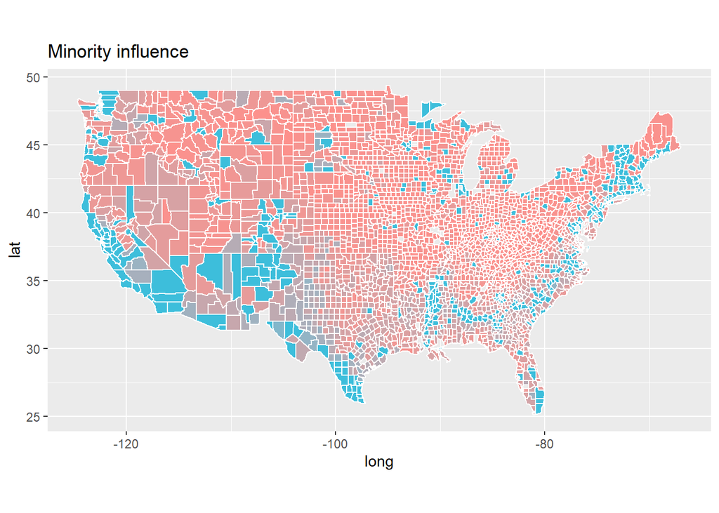

We also visualize the `Minority` and `Income`. We observe that higher minority is correlated with lesser income. Higher minority also means a higher likelihood for Hillary winning.

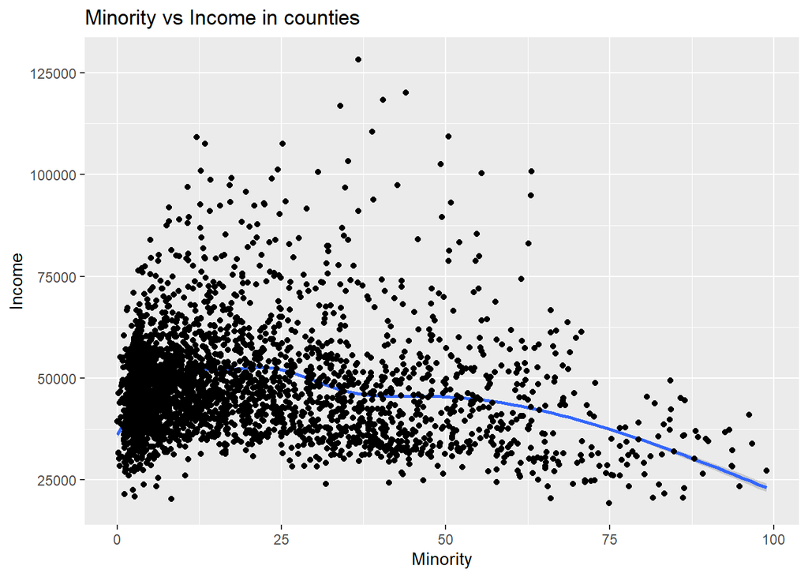

We see a more uniform distribution for the income per capita of Hillary voters than that of Donald Trump. His is more like a Gaussian distribution. And a `geom_boxplot` also shows that generally, if a county has gone to Trump then its income per capita is lower than a county that has gone for Hillary.

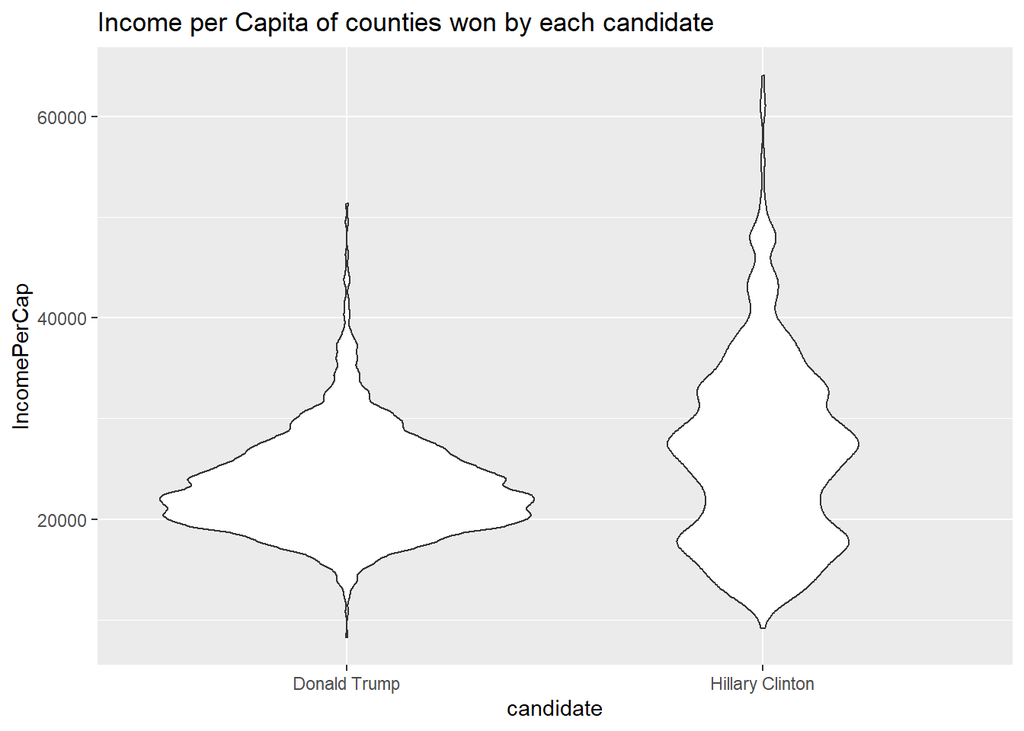

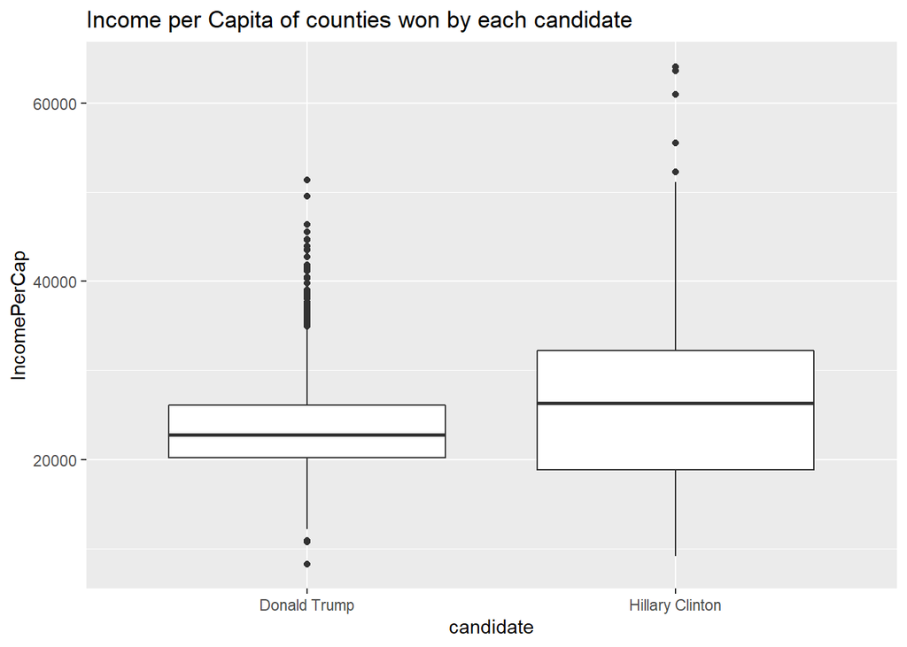

A rural county generally goes to Trump. We can see this by looking at the county population (log-scaled) plot below.

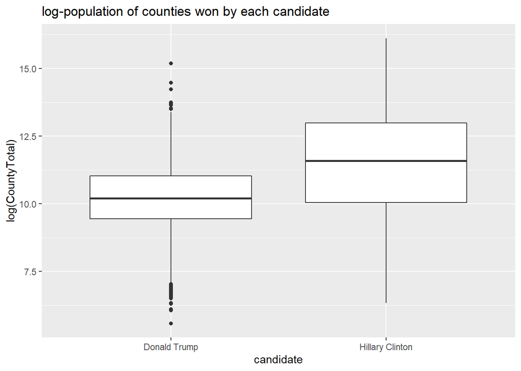

Focusing on the decisive Blue Wall states (will be talked about later), we visualize which candidate won the richer/poorer counties in each of these states:

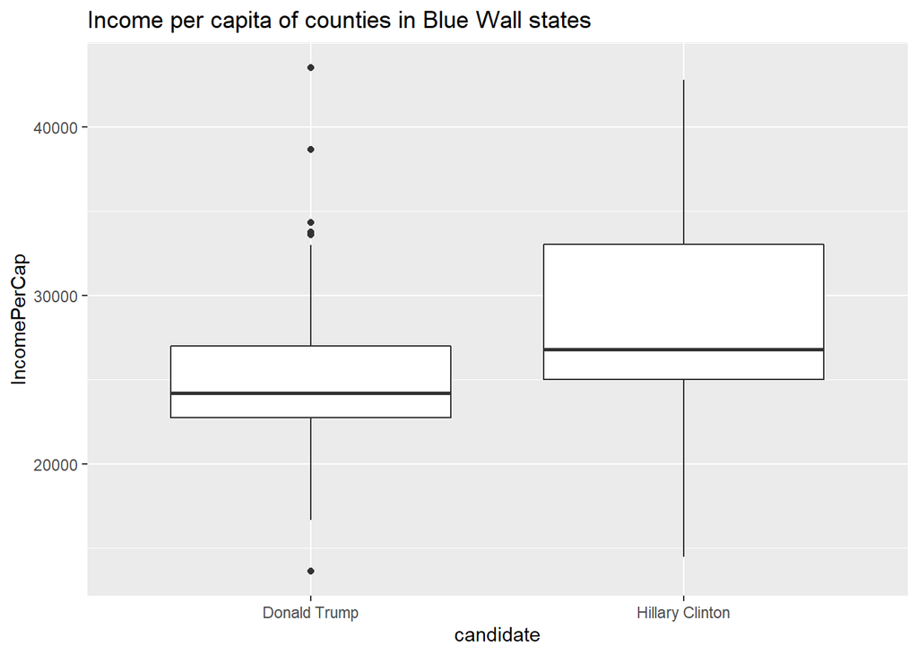

# 4- Dimensionality reduction

14. We perform PCA on `census.ct` and `census.ct`. We choose to scale and center the features because if some features have large variance and some small, then PCA will decide that the features with large variance will explain all variation in the data.

The features of `census.ct` with the largest absolute values of the first principal component are

| Features |
| --- |
| IncomePerCapErr |
| IncomePerCap |
| SelfEmployed |

The features of `census.subct` with the largest absolute values of the first principal component are

| Features |
| --- |
| IncomePerCap |
| IncomePerCapErr |
| ChildPoverty |

15. We plot the PVE and cumulative PVE for the `census.ct` PCA:

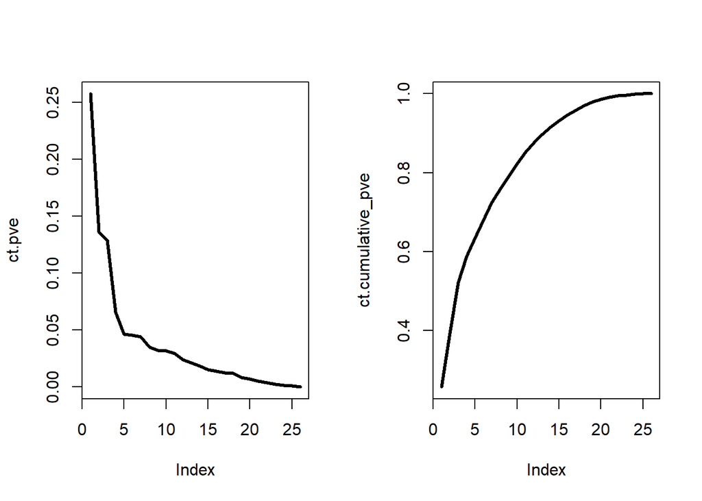

The number of PCs which capture 90% of the variance is 13.

We plot the PVE and cumulative PVE for the `census.subct` PCA:

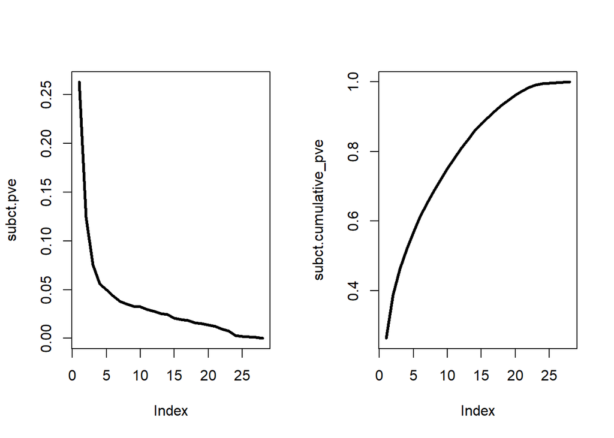

The number of PCs for `subct` which capture 90% of the variance is 16.

# 5- Clustering

16. We perform hierarchical clustering on `census.ct` with complete linkage and cut to 10 clusters. We do the same instead using the first five principal components.

We want to know which clustering is more appropriate for San Mateo county. San Mateo county went to Clinton. In order to determine which cluster is more appropriate, we will see which cluster has a higher percentage of Clinton.

The following table is the count of Clinton/Trump in the cluster with San Mateo county of the clustering on all of `census.ct`:

count of Clinton/Trump in the cluster with San Mateo county of the full clustering

| Candidate | Count |
| --- | --- |
| Donald Trump | 169 |
| Hillary Clinton | 78 |

The following table is the count of Clinton/Trump in the cluster with San Mateo county of the clustering on first five principal components of `census.ct`:

count of Clinton/Trump in the cluster with San Mateo county of the PC5 clustering

| Candidate | Count |
| --- | --- |
| Donald Trump | 77 |
| Hillary Clinton | 54 |

The clustering with the first five principal components is more appropriate since the proportion of Hillary is higher than in the other cluster.

# 6- Classification

On top of the data that is defined by the handout given by combining `county_winner` and `census` datas, we also build data frames on the winner of the election at county levels and the results of each county and state for each of the three main candidates. These dataframes will be used in **Further Exploration** part and Question 21.

Further for future usage, we define our version of train-test partitioning and folds for the county and state results for the three main candidates.

Finally, we will also use the `records` and `calc_error_rate` functions provided by the handout.

17. Decision tree: We first define the `tree.control` parameters and apply `tree()` on the training data set to obtain the following tree.

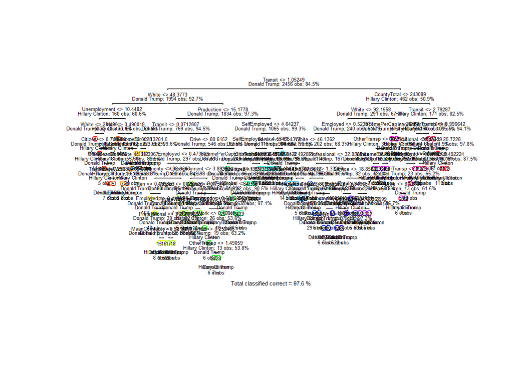

| best tree size |
| --- |
| 12 |

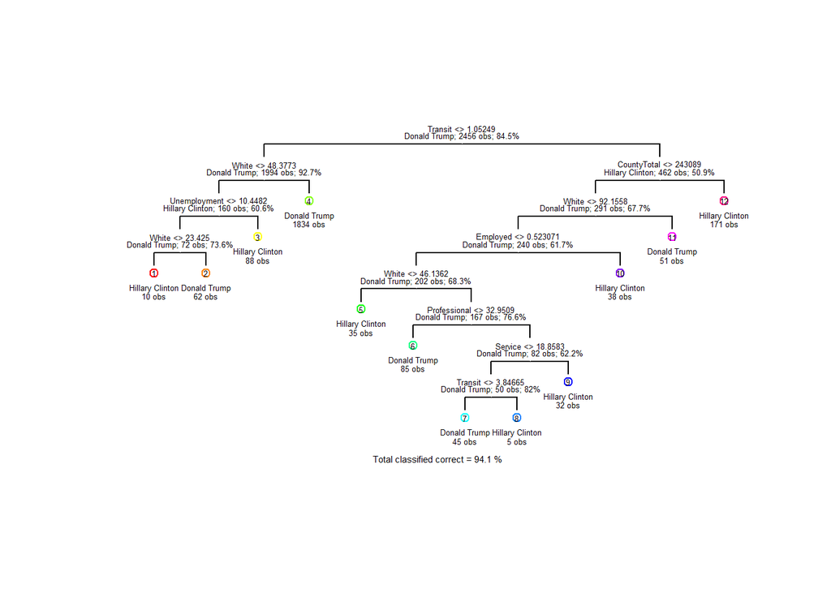

Intepret and discuss the results of the decision tree analysis. Use this plot to tell a story about voting behavior in the US

**ANSWER**: Discussion of the results:

We next perform the predictions and calculate the error rates and record them in `records`.

|  | train.error | test.error |
| --- | --- | --- |
| tree | 0.0586319 | 0.0650407 |
| logistic | NA | NA |
| lasso | NA | NA |

18. We do the glm fit and will calculate all errors by majority rule (threshold $0.5$). We print a summary; we observe that the significant variables are (ignore the `intercept`):

|  | Estimate | Std. Error | z value | Pr(>\|z\|) |
| --- | --- | --- | --- | --- |
| (Intercept) | -24.8707796 | 9.4517341 | -2.6313457 | 0.0085047 |
| Men | 9.5892512 | 4.8237869 | 1.9879094 | 0.0468217 |
| White | -0.1688549 | 0.0676264 | -2.4968803 | 0.0125291 |
| Citizen | 13.0214787 | 2.7958234 | 4.6574755 | 0.0000032 |
| Income | -0.0000871 | 0.0000273 | -3.1915178 | 0.0014153 |
| IncomeErr | -0.0000033 | 0.0000637 | -0.0522502 | 0.9583293 |
| IncomePerCap | 0.0002671 | 0.0000670 | 3.9866955 | 0.0000670 |
| IncomePerCapErr | -0.0003605 | 0.0001715 | -2.1015056 | 0.0355966 |
| Poverty | 0.0474140 | 0.0405184 | 1.1701846 | 0.2419267 |
| ChildPoverty | -0.0158227 | 0.0245772 | -0.6437950 | 0.5197084 |
| Professional | 0.2802314 | 0.0387041 | 7.2403549 | 0.0000000 |
| Service | 0.3242049 | 0.0475762 | 6.8144365 | 0.0000000 |
| Office | 0.0759023 | 0.0446543 | 1.6997762 | 0.0891730 |
| Production | 0.1668326 | 0.0409314 | 4.0759068 | 0.0000458 |
| Drive | -0.2096881 | 0.0461686 | -4.5417851 | 0.0000056 |
| Carpool | -0.1735883 | 0.0592939 | -2.9275920 | 0.0034160 |
| Transit | 0.0757799 | 0.0942418 | 0.8041010 | 0.4213386 |
| OtherTransp | -0.0625798 | 0.0950312 | -0.6585181 | 0.5102052 |
| WorkAtHome | -0.1657167 | 0.0719832 | -2.3021572 | 0.0213263 |
| MeanCommute | 0.0561566 | 0.0242154 | 2.3190470 | 0.0203925 |
| Employed | 20.5641902 | 3.3537361 | 6.1317258 | 0.0000000 |
| PrivateWork | 0.1010086 | 0.0218880 | 4.6148027 | 0.0000039 |
| SelfEmployed | 0.0196807 | 0.0467755 | 0.4207469 | 0.6739399 |
| FamilyWork | -0.8873246 | 0.3765022 | -2.3567578 | 0.0184353 |
| Unemployment | 0.2072704 | 0.0397117 | 5.2193780 | 0.0000002 |
| Minority | -0.0305324 | 0.0650909 | -0.4690736 | 0.6390171 |
| CountyTotal | 0.0000004 | 0.0000004 | 0.8167849 | 0.4140514 |

| Significant Variables |
| --- |
| Men |
| White |
| Citizen |
| Income |
| IncomePerCap |
| IncomePerCapErr |
| Professional |
| Service |
| Production |
| Drive |
| Carpool |
| WorkAtHome |
| MeanCommute |
| Employed |
| PrivateWork |
| FamilyWork |
| Unemployment |

We perform the predictions and store the errors inside records.

|  | train.error | test.error |
| --- | --- | --- |
| tree | 0.0586319 | 0.0650407 |
| logistic | 0.0704397 | 0.0634146 |
| lasso | NA | NA |

My county has **unique** population $432687$ and it can be found only in `tst.cl`. So we check glm response to be higher than $0.5$ to account for Hillary Clinton and be a true prediction. The prediction turns out to be correct.

Hillary Clinton

| Santa Barbara |
| --- |

19. Before doing glmnet we need to make sure to refactor the candidate levels to only two levels and put the dataframe into a matrix (which means we also forgo the candiate column). After applying `cv.glmnet` we get the best value of lambda with minimum misclassification error which is

| best lambda value |
| --- |
| 0.0003612 |

|  | Coefficients |
| --- | --- |
| (Intercept) | -26.7510285 |
| Men | 7.6493590 |
| White | -0.1314957 |
| Citizen | 13.3760162 |
| Income | -0.0000678 |
| IncomeErr | -0.0000114 |
| IncomePerCap | 0.0002205 |
| IncomePerCapErr | -0.0002825 |
| Poverty | 0.0376264 |
| ChildPoverty | -0.0054864 |
| Professional | 0.2603600 |
| Service | 0.3009100 |
| Office | 0.0595271 |
| Production | 0.1440781 |
| Drive | -0.1875627 |
| Carpool | -0.1501083 |
| Transit | 0.0895624 |
| OtherTransp | -0.0317813 |
| WorkAtHome | -0.1336618 |
| MeanCommute | 0.0438980 |
| Employed | 19.6970960 |
| PrivateWork | 0.0942985 |
| SelfEmployed | 0.0028237 |
| FamilyWork | -0.7826734 |
| Unemployment | 0.1974977 |
| Minority | 0.0000000 |
| CountyTotal | 0.0000004 |

As to how they compare to glm, we see coefficients being generally smaller, as it should be since we are penalizing their norm. But we also see a bigger coefficient for `Transit` and `CountyTotal`, the two variables that glm was not taking as significant in contrast to decision tree.

|  | Percentage difference of glmnet vs glm |
| --- | --- |
| (Intercept) | 0.0756007 |
| Men | -0.2022986 |
| White | -0.2212503 |
| Citizen | 0.0272271 |
| Income | -0.2216677 |
| IncomeErr | 2.4368799 |
| IncomePerCap | -0.1744409 |
| IncomePerCapErr | -0.2162432 |
| Poverty | -0.2064296 |
| ChildPoverty | -0.6532550 |
| Professional | -0.0709105 |
| Service | -0.0718524 |
| Office | -0.2157405 |
| Production | -0.1363907 |
| Drive | -0.1055153 |
| Carpool | -0.1352623 |
| Transit | 0.1818751 |
| OtherTransp | -0.4921474 |
| WorkAtHome | -0.1934315 |
| MeanCommute | -0.2182937 |
| Employed | -0.0421652 |
| PrivateWork | -0.0664309 |
| SelfEmployed | -0.8565243 |
| FamilyWork | -0.1179402 |
| Unemployment | -0.0471498 |
| Minority | -1.0000000 |
| CountyTotal | 0.1297702 |

We perform the predictions and store them in records

|  | train.error | test.error |
| --- | --- | --- |
| tree | 0.0586319 | 0.0650407 |
| logistic | 0.0704397 | 0.0634146 |
| lasso | 0.0696254 | 0.0650407 |

20. Plotting the ROC curves:

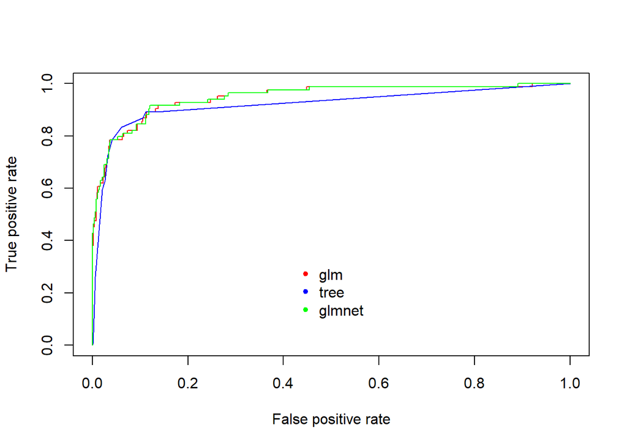

And here is the colorized with threshold guide.

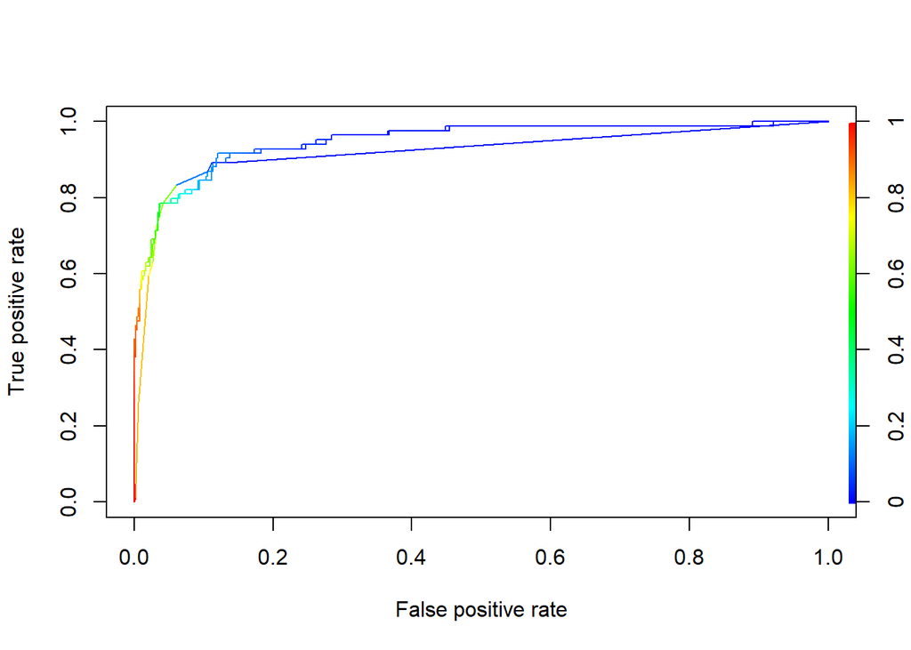

Computing the AUCs:

|  | AUC values |
| --- | --- |
| tree | 0.9202202 |
| glm | 0.9482782 |
| LASSO | 0.9487938 |

By AUC metric, we see that glm and glmnet are doing better than tree. To compare all models let us review their errors at the same time.

|  | train.error | test.error |
| --- | --- | --- |
| tree | 0.0586319 | 0.0650407 |
| logistic | 0.0704397 | 0.0634146 |
| lasso | 0.0696254 | 0.0650407 |

We should be careful that the threshold chosen for logistic and lasso were set to $0.5$ and by AUC score, it looks like better values can be chosen to lower the train and test error. But sometimes it would be better to choose a model depending on the question.

For example, if the question is generally asking about whether for a county with (variable $X >$ some threshold), we can predict with good accuracy a result, then decision tree performs better; esp. if that variable is something like `Transit`.

It is important to note that for the general election prediction, one needs to have a good look at how these models perfom at the electoral level. Then, perhaps we could make a decision as to which model could be the best model when it comes to the most important (winner) prediction.

21. We store the errors of the lasso prediction with the dataset containing the fips. This will make it easy to merge with counties.

Visualizing the error maps

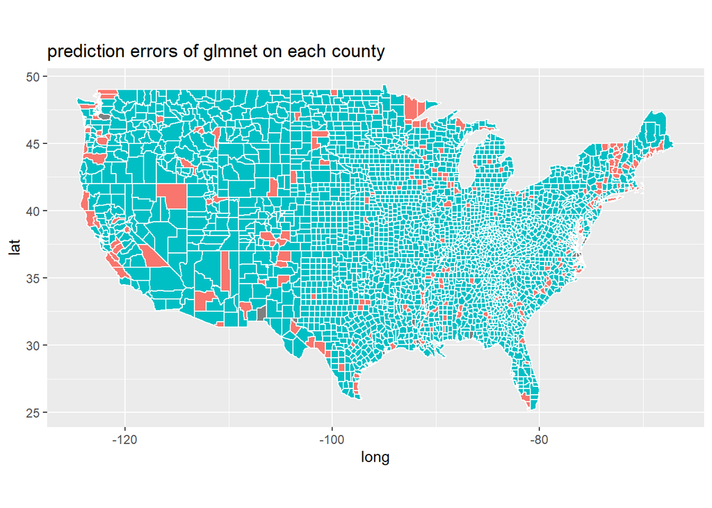

Green is right and red is wrong prediction. We see a bunch of misses on the North east, a couple on California coast, and a bunch in states to the west of Central US like Colorado, New Mexico and Arizona; almost all of which are also purple counties per the real data: https://www.nytimes.com/elections/2016/results/president.

Insights gained: The insights gained from each of the models have been discussed already in their analysis. Some of the other classifiers used in the further exploration part give better results but their improvement is due to a slightly more accurate learning of the interaction between variables and winner results.

Possible Directions: One of the surprises of 2016 election was the fall of the so-called Blue Wall: https://en.wikipedia.org/wiki/Blue_wall_(politics)#Demise_of_the_blue_wall; The states Pennsylvania, Michigan and Wisconsin went to Trump which was not predicted by most models including FiveThirtyEight. Our model seems to predict well in those states with some misses, but it is important to emphasize that Clinton lost Wisconsin by about 20,000, Pennsylvania by about 50,000 and Michigan by about 10,000. And if Hillary hadn’t lost these states, she would have been the winner with 273 electoral votes.

This means that even with having all the post-election data, we may not have been able to predict these states correctly because of the few misses we had or because if we were to predict the total votes then we would have **underestimated** Trump’s performance in rural parts that were even correctly predicted to go to him. It is therefore important to see what the models do at determining the **nunber** of votes but also how they do at state level. This will be part of the **Further Exploration** below.

It is of course the case that additional data could help reduce the errors. Also trying to find out similar occurences in previous presidential elections and considering their data could be of help. One could also try a separate analysis of the three decisive states which Hillary lost narrowly. One of the theories behind her lost is due to the trade deal NAFTA (signed during her husband Bill Clinton presidency) which resulted in many jobs being shipped out of those states. Therefore, we could also test this theory by having additional data on the history of the workers in those states. If this theory stands, it would not be surprising to see high percentage of White blue-collar workers (i.e. employed in jobs like Production/Construction but not Professional/Office/Service) now being unemployed or employed in lower paying service jobs; and exit polls would then illustrate whether those people had a major turnout and voted for Trump.

# FURTHER EXPLORATION:

Visualizing the continuous predictions to find out purple counties:

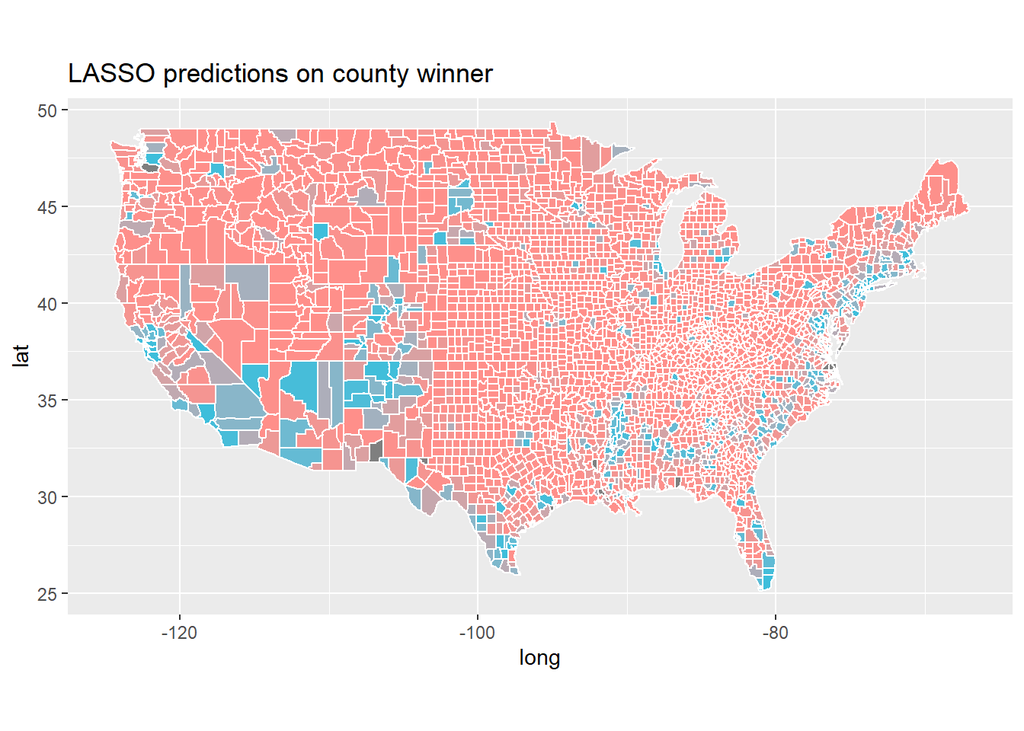

The above is the prediction map. The more blue it is the more certain the LASSO model is about Hillary Clinton success. The more red the more certain it is for Trump. Interestingly, the purple counties mostly seem to appear in states that were not marginally won like those in the Blue Wall states, telling us more about the necessity of an analysis at the state level.

To get the purple counties, we determine an interval of $0.1$ around the threshold $0.5$

| number of purple counties |
| --- |
| 112 |

# 1- Data preprocessing

Data preprocessing: we aggregated sub-county level data before performing classification. Would classification at the sub-county level before determining the winner perform better? What implicit assumptions are we making?

**ANSWER**: It could be that in certain subcounties of a county the voting turnout is higher than other subcounties with similar citizen populations, while they vote differently (for example consider a suburban area far away from the downtown and the downtown itself). What we are assuming here is that as counties are relatively small areas of populations, such variances should not be really high and people voting behavior should be similar. Therefore the aggregation which is done by the weighting by population should be enough and we don’t need a more sophisticated weighting which comes from a measure of voting behavior (hence voting impact) beyond just the citizen population in each subcounty.

So there might be some potential in a better model if analysis is performed at a subcounty level. But this performance gain may not be that high to warrant a more involved and time consuming data analysis.

But in the end, in order to be really sure, we have to either perform the analysis or a more involved direction would be to analyze the variance of voting turnout in many elections in subcounties of each county and do the weighting according to the voting turnout.

# 2- Analysis of the county and state vote

Here we use dataframes we built for the main three candidates at county and state level to predict the number of votes using `lm`. We will then visualize the results and compare them to the actual results.

We print their summaries.

Donald Trump

|  | Estimate | Std. Error | t value | Pr(>\|t\|) |
| --- | --- | --- | --- | --- |
| (Intercept) | -1.256059e+04 | 2.824495e+04 | -0.4447023 | 0.6565746 |
| total | 4.854293e-01 | 1.372710e-02 | 35.3627884 | 0.0000000 |
| Men | -3.063174e+04 | 1.480846e+04 | -2.0685294 | 0.0386959 |
| White | -2.653636e+02 | 1.867548e+02 | -1.4209197 | 0.1554685 |
| Citizen | -2.825811e+04 | 9.173248e+03 | -3.0804918 | 0.0020898 |
| Income | 3.870356e-01 | 8.323550e-02 | 4.6498837 | 0.0000035 |
| IncomeErr | 4.850850e-02 | 1.810307e-01 | 0.2679572 | 0.7887550 |
| IncomePerCap | -9.306285e-01 | 1.999417e-01 | -4.6544987 | 0.0000034 |
| IncomePerCapErr | 1.091537e+00 | 4.436915e-01 | 2.4601264 | 0.0139580 |
| Poverty | -2.332230e+02 | 1.412305e+02 | -1.6513649 | 0.0987934 |
| ChildPoverty | 1.134099e+02 | 7.856289e+01 | 1.4435553 | 0.1489931 |
| Professional | 3.178516e+02 | 1.072103e+02 | 2.9647493 | 0.0030588 |
| Service | 3.971134e+02 | 1.211853e+02 | 3.2769111 | 0.0010643 |
| Office | 8.226488e+02 | 1.240951e+02 | 6.6291826 | 0.0000000 |
| Production | -2.248415e+02 | 1.037738e+02 | -2.1666505 | 0.0303585 |
| Drive | 2.370592e+02 | 1.518356e+02 | 1.5612883 | 0.1185861 |
| Carpool | 8.866806e+01 | 1.910808e+02 | 0.4640343 | 0.6426648 |
| Transit | -1.605878e+03 | 2.150428e+02 | -7.4677129 | 0.0000000 |
| OtherTransp | -3.630698e+01 | 3.178383e+02 | -0.1142310 | 0.9090641 |
| WorkAtHome | 4.705220e+02 | 2.191010e+02 | 2.1475119 | 0.0318513 |
| MeanCommute | 2.041216e+00 | 7.280664e+01 | 0.0280361 | 0.9776356 |
| Employed | -1.017655e+04 | 9.405288e+03 | -1.0820025 | 0.2793589 |
| PrivateWork | 4.606461e+02 | 6.667440e+01 | 6.9088903 | 0.0000000 |
| SelfEmployed | 3.148186e+01 | 1.326284e+02 | 0.2373689 | 0.8123907 |
| FamilyWork | 7.311742e+02 | 7.782955e+02 | 0.9394558 | 0.3475902 |
| Unemployment | 1.991327e+02 | 1.303174e+02 | 1.5280595 | 0.1266280 |
| Minority | -3.258176e+02 | 1.856330e+02 | -1.7551709 | 0.0793562 |
| CountyTotal | -7.128510e-02 | 5.205300e-03 | -13.6947082 | 0.0000000 |

Hillary Clinton

|  | Estimate | Std. Error | t value | Pr(>\|t\|) |
| --- | --- | --- | --- | --- |
| (Intercept) | 4180.9793417 | 2613.3786118 | 1.5998368 | 0.1097649 |
| total | 0.0397596 | 0.0012701 | 31.3040533 | 0.0000000 |
| Men | 4268.8628657 | 1370.1605452 | 3.1155932 | 0.0018572 |
| White | -102.4089905 | 17.2795828 | -5.9265893 | 0.0000000 |
| Citizen | -1485.8382443 | 848.7594548 | -1.7505999 | 0.0801411 |
| Income | 0.0226195 | 0.0077014 | 2.9370555 | 0.0033446 |
| IncomeErr | -0.0072226 | 0.0167500 | -0.4312011 | 0.6663605 |
| IncomePerCap | 0.0059673 | 0.0184997 | 0.3225624 | 0.7470544 |
| IncomePerCapErr | -0.0085632 | 0.0410528 | -0.2085912 | 0.8347849 |
| Poverty | 49.1125804 | 13.0674208 | 3.7583989 | 0.0001750 |
| ChildPoverty | -8.5816650 | 7.2690716 | -1.1805724 | 0.2378883 |
| Professional | 26.4076616 | 9.9196852 | 2.6621471 | 0.0078156 |
| Service | 10.3590924 | 11.2127309 | 0.9238688 | 0.3556464 |
| Office | -5.8381304 | 11.4819596 | -0.5084612 | 0.6111762 |
| Production | 0.9714647 | 9.6017227 | 0.1011761 | 0.9194190 |
| Drive | 13.3053428 | 14.0486696 | 0.9470892 | 0.3436876 |
| Carpool | 31.1761412 | 17.6798512 | 1.7633712 | 0.0779637 |
| Transit | -188.0877817 | 19.8969445 | -9.4530988 | 0.0000000 |
| OtherTransp | 62.0128913 | 29.4081492 | 2.1086975 | 0.0350729 |
| WorkAtHome | 29.7386057 | 20.2724324 | 1.4669481 | 0.1425197 |
| MeanCommute | -11.5019441 | 6.7364715 | -1.7074138 | 0.0878730 |
| Employed | 1999.1930906 | 870.2291204 | 2.2973181 | 0.0216853 |
| PrivateWork | 5.6484648 | 6.1690829 | 0.9156085 | 0.3599632 |
| SelfEmployed | -22.1571937 | 12.2715140 | -1.8055795 | 0.0711079 |
| FamilyWork | -24.4485179 | 72.0121873 | -0.3395053 | 0.7342585 |
| Unemployment | 11.9527589 | 12.0576806 | 0.9912983 | 0.3216387 |
| Minority | -107.4838320 | 17.1757873 | -6.2578693 | 0.0000000 |
| CountyTotal | -0.0037675 | 0.0004816 | -7.8225036 | 0.0000000 |

Gary Johnson

[output not shown]

We do the same thing at the state level; notice here we will use the full data as we don’t have many observations.

Donald Trump

|  | Estimate | Std. Error | t value | Pr(>\|t\|) |
| --- | --- | --- | --- | --- |
| (Intercept) | 4.145360e+07 | 3.261442e+07 | 1.2710207 | 0.2169967 |
| total | 6.385329e-01 | 1.626451e-01 | 3.9259273 | 0.0007224 |
| Men | -3.494651e+07 | 3.090075e+07 | -1.1309276 | 0.2702640 |
| White | -1.472476e+04 | 3.868888e+04 | -0.3805940 | 0.7071546 |
| Citizen | -4.154490e+06 | 5.204874e+06 | -0.7981921 | 0.4332912 |
| Income | 8.478777e+01 | 6.586425e+01 | 1.2873110 | 0.2113650 |
| IncomeErr | -3.539275e+02 | 2.299280e+02 | -1.5392970 | 0.1379924 |
| IncomePerCap | -3.255095e+01 | 1.120851e+02 | -0.2904128 | 0.7742204 |
| IncomePerCapErr | 6.378716e+02 | 5.977458e+02 | 1.0671286 | 0.2974847 |
| Poverty | -1.906162e+05 | 1.447297e+05 | -1.3170494 | 0.2013764 |
| ChildPoverty | 2.710334e+05 | 1.125071e+05 | 2.4090332 | 0.0248091 |
| Professional | -1.279291e+05 | 1.174318e+05 | -1.0893910 | 0.2877712 |
| Service | -5.262032e+04 | 9.175399e+04 | -0.5734935 | 0.5721271 |
| Office | -4.662801e+04 | 1.030607e+05 | -0.4524326 | 0.6553871 |
| Production | -8.186311e+04 | 9.409176e+04 | -0.8700349 | 0.3936755 |
| Drive | -1.951724e+05 | 1.412575e+05 | -1.3816781 | 0.1809419 |
| Carpool | -2.075270e+05 | 1.802359e+05 | -1.1514186 | 0.2619204 |
| Transit | -2.442493e+05 | 1.697109e+05 | -1.4392078 | 0.1641689 |
| OtherTransp | -2.143762e+05 | 2.697570e+05 | -0.7947012 | 0.4352772 |
| WorkAtHome | -1.403653e+05 | 1.445555e+05 | -0.9710131 | 0.3420973 |
| MeanCommute | 1.527183e+04 | 4.788417e+04 | 0.3189327 | 0.7527859 |
| Employed | -1.301325e+06 | 6.007362e+06 | -0.2166217 | 0.8304993 |
| PrivateWork | 4.177508e+04 | 3.677730e+04 | 1.1358929 | 0.2682245 |
| SelfEmployed | -8.425971e+04 | 1.001833e+05 | -0.8410558 | 0.4093656 |
| FamilyWork | 1.602178e+06 | 1.129082e+06 | 1.4190100 | 0.1699094 |
| Unemployment | -1.877248e+05 | 1.014288e+05 | -1.8508045 | 0.0776716 |
| Minority | -2.042386e+04 | 4.363589e+04 | -0.4680519 | 0.6443513 |
| StateTotal | -9.604160e-02 | 6.722800e-02 | -1.4285962 | 0.1671651 |

Hillary Clinton

|  | Estimate | Std. Error | t value | Pr(>\|t\|) |
| --- | --- | --- | --- | --- |
| (Intercept) | -2.624369e+07 | 2.882634e+07 | -0.9104067 | 0.3724755 |
| total | 3.706637e-01 | 1.437543e-01 | 2.5784530 | 0.0171434 |
| Men | 2.240194e+07 | 2.731171e+07 | 0.8202322 | 0.4208824 |
| White | 9.242613e+03 | 3.419527e+04 | 0.2702893 | 0.7894571 |
| Citizen | 2.911876e+06 | 4.600342e+06 | 0.6329696 | 0.5332784 |
| Income | -7.545992e+01 | 5.821429e+01 | -1.2962440 | 0.2083250 |
| IncomeErr | 2.973597e+02 | 2.032225e+02 | 1.4632224 | 0.1575482 |
| IncomePerCap | 4.233240e+01 | 9.906671e+01 | 0.4273121 | 0.6733053 |
| IncomePerCapErr | -5.412386e+02 | 5.283192e+02 | -1.0244539 | 0.3167543 |
| Poverty | 1.610744e+05 | 1.279197e+05 | 1.2591831 | 0.2211610 |
| ChildPoverty | -2.347187e+05 | 9.943972e+04 | -2.3604114 | 0.0275361 |
| Professional | 8.111051e+04 | 1.037924e+05 | 0.7814688 | 0.4428560 |
| Service | 3.263574e+04 | 8.109700e+04 | 0.4024285 | 0.6912522 |
| Office | 3.363743e+04 | 9.109044e+04 | 0.3692750 | 0.7154532 |
| Production | 6.119332e+04 | 8.316325e+04 | 0.7358216 | 0.4696124 |
| Drive | 1.357664e+05 | 1.248508e+05 | 1.0874294 | 0.2886177 |
| Carpool | 1.346700e+05 | 1.593020e+05 | 0.8453759 | 0.4070016 |
| Transit | 1.741455e+05 | 1.499995e+05 | 1.1609744 | 0.2580951 |
| OtherTransp | 1.348805e+05 | 2.384254e+05 | 0.5657135 | 0.5773136 |
| WorkAtHome | 9.759362e+04 | 1.277658e+05 | 0.7638478 | 0.4530728 |
| MeanCommute | -8.239685e+03 | 4.232255e+04 | -0.1946878 | 0.8474240 |
| Employed | 1.606382e+06 | 5.309622e+06 | 0.3025416 | 0.7650812 |
| PrivateWork | -4.473296e+04 | 3.250572e+04 | -1.3761568 | 0.1826208 |
| SelfEmployed | 6.865687e+04 | 8.854724e+04 | 0.7753700 | 0.4463761 |
| FamilyWork | -1.278570e+06 | 9.979419e+05 | -1.2812065 | 0.2134620 |
| Unemployment | 1.696123e+05 | 8.964807e+04 | 1.8919789 | 0.0717296 |
| Minority | 1.518806e+04 | 3.856770e+04 | 0.3938026 | 0.6975177 |
| StateTotal | 7.364510e-02 | 5.941960e-02 | 1.2394063 | 0.2282545 |

Gary Johnson

|  | Estimate | Std. Error | t value | Pr(>\|t\|) |
| --- | --- | --- | --- | --- |
| (Intercept) | -2.557857e+06 | 2.630642e+06 | -0.9723320 | 0.3414556 |
| total | -2.088500e-03 | 1.311880e-02 | -0.1591985 | 0.8749650 |
| Men | 2.711339e+06 | 2.492419e+06 | 1.0878343 | 0.2884429 |
| White | -5.652097e+03 | 3.120601e+03 | -1.8112209 | 0.0837836 |
| Citizen | -1.251688e+05 | 4.198192e+05 | -0.2981493 | 0.7683869 |
| Income | -2.861712e+00 | 5.312535e+00 | -0.5386716 | 0.5955226 |
| IncomeErr | -1.006596e+00 | 1.854573e+01 | -0.0542764 | 0.9572048 |
| IncomePerCap | 6.036890e+00 | 9.040656e+00 | 0.6677491 | 0.5112386 |
| IncomePerCapErr | -1.355664e+01 | 4.821349e+01 | -0.2811794 | 0.7812004 |
| Poverty | 1.159499e+04 | 1.167373e+04 | 0.9932543 | 0.3313857 |
| ChildPoverty | -4.640622e+03 | 9.074697e+03 | -0.5113804 | 0.6141792 |
| Professional | 8.042195e+03 | 9.471914e+03 | 0.8490571 | 0.4049942 |
| Service | 4.589431e+03 | 7.400772e+03 | 0.6201287 | 0.5415439 |
| Office | -1.005990e+04 | 8.312756e+03 | -1.2101765 | 0.2390538 |
| Production | 3.619373e+03 | 7.589334e+03 | 0.4769027 | 0.6381345 |
| Drive | 1.368874e+04 | 1.139367e+04 | 1.2014340 | 0.2423576 |
| Carpool | 1.301442e+04 | 1.453762e+04 | 0.8952237 | 0.3803582 |
| Transit | 1.309100e+04 | 1.368869e+04 | 0.9563372 | 0.3492937 |
| OtherTransp | 1.764764e+04 | 2.175829e+04 | 0.8110767 | 0.4260097 |
| WorkAtHome | 2.647348e+04 | 1.165968e+04 | 2.2705145 | 0.0333172 |
| MeanCommute | 1.272480e+03 | 3.862283e+03 | 0.3294632 | 0.7449218 |
| Employed | 3.700735e+05 | 4.845469e+05 | 0.7637516 | 0.4531289 |
| PrivateWork | 1.385172e+03 | 2.966415e+03 | 0.4669513 | 0.6451262 |
| SelfEmployed | -9.218763e+03 | 8.080667e+03 | -1.1408418 | 0.2662031 |
| FamilyWork | -3.820843e+04 | 9.107045e+04 | -0.4195481 | 0.6788843 |
| Unemployment | 7.993917e+03 | 8.181128e+03 | 0.9771168 | 0.3391344 |
| Minority | -6.427021e+03 | 3.519621e+03 | -1.8260549 | 0.0814460 |
| StateTotal | 1.257560e-02 | 5.422500e-03 | 2.3191428 | 0.0300648 |

In the case of counties, we see similar patterns of significant coefficients repeating themselves with `Men`, `Income`, `Transit`, `Minority` being among the significant coefficients as we saw in the previous classification models. One can also observe some variance as to which coefficients are significant among the candidates.

But when it comes to states, perhaps due to low number of states compared to the variables we have, we don’t have many significant coefficients and there are a lot of uncertainty. We obtain significance mostly on the population of the total number of votes and sometimes `ChildPoverty`. An alternative direction is to perform a direct prediction of the states by applying our counties model at the state level (which has been trained with far more observations); we will have to change the `StateTotal` variable to `CountyTotal`. This is akin to thinking of states as huge counties.

But the problem with this idea is that the coefficients should become much larger as we can see by comparing the coefficients of the lm at each county and state level above.

Let us see how the linear models do at the state level for the Blue Wall states:

|  | (Trump - Hillary) votes |
| --- | --- |
| Pennsylvania | -208953.26 |
| Michigan | -132830.33 |
| Wisconsin | 15791.45 |

The model predicts Trump losing in two of these states but winning in one of them (Wisconsin). The margin by which he wins in Wisconsin is close to 20,000 which is about the margin by which he actually won.

Let us now apply the lm at county level on the state data just to check whether it fails badly or not due to improper scaling:

|  | (Trump - Hillary) votes |
| --- | --- |
| Pennsylvania | -1686858.1 |
| Michigan | -1285070.1 |
| Wisconsin | -743981.1 |

In general, linear models are pretty efficient and easy estimator to start with. Also the most important thing in an election is the number of votes which lms can predict directly. Glm can predict indirectly by multiplying the probability of winning of each county by the TotalVotes in that county. But overall, lm’s must be complemented with other classifiers. For example a data analyst of the presidential campaign must use glm to know better how the odds of winning change based on a unit change in the variables. The tree model also gives an overview of how to perhaps strategize campaigning as it provides a certain hierarchy of importance for variables.

# 3- Exploring other classifiers

**LDA AND QDA**

We predict the candidate using lda and qda on the same election data that we used for previous classifiers.

Here is the ROC plot:

[figure not shown]

Here is the plot with the threshold guide:

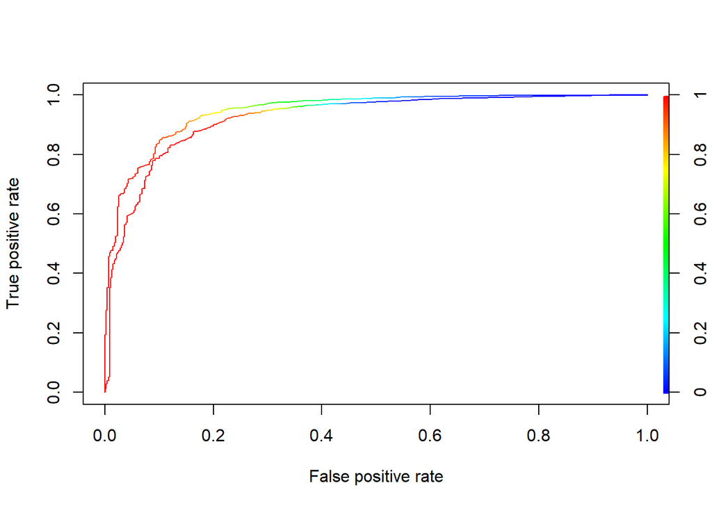

The AUC values are:

|  | AUC values |
| --- | --- |
| tree | 0.9202202 |
| glm | 0.9482782 |
| LASSO | 0.9487938 |
| LDA | 0.9470164 |
| QDA | 0.9230919 |

|  | train.error | test.error |
| --- | --- | --- |
| tree | 0.0586319 | 0.0650407 |
| logistic | 0.0704397 | 0.0634146 |
| lasso | 0.0696254 | 0.0650407 |
| LDA | 0.0700326 | 0.0699187 |
| QDA | 0.0887622 | 0.0796748 |
| SVM | NA | NA |
| TUNE.SVM | NA | NA |
| SVM_on_PC | NA | NA |

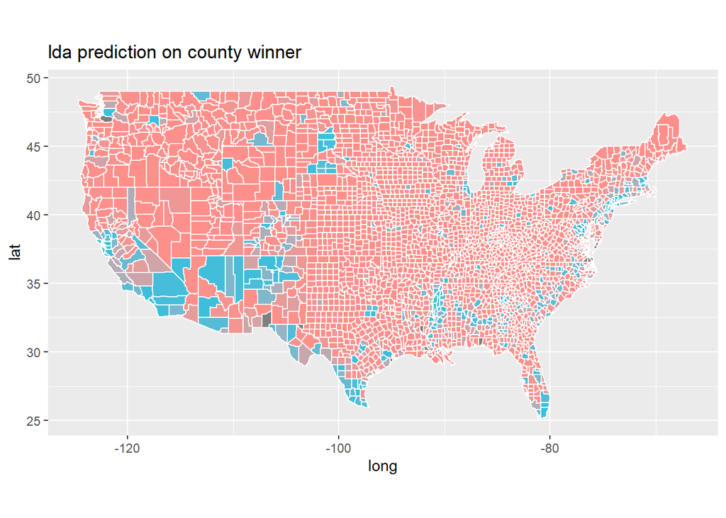

Let us count the number of purple counties with the threshold $0.4$ to $0.6$:

| number of purple counties |
| --- |
| 94 |

This is smaller than $120$ for the same thresholds for glmnet. So there is less uncertainty than glmnet.

**SVM**

We will implement a cross validation of svm over grid values of `cost` and `gamma`. `tune.svm()` performs 10 fold cross validation on $10\times 10$ grids, therefore a $1000$ runs. This takes some time (about 30 minutes) so what we will also implement is one svm with a fixed chosen value of `gamma` and `cost`. We store the results in `new_records` and print them.

|  | train.error | test.error |
| --- | --- | --- |
| tree | 0.0586319 | 0.0650407 |
| logistic | 0.0704397 | 0.0634146 |
| lasso | 0.0696254 | 0.0650407 |
| LDA | 0.0700326 | 0.0699187 |
| QDA | 0.0887622 | 0.0796748 |
| SVM | 0.0358306 | 0.0504065 |
| TUNE.SVM | NA | NA |
| SVM_on_PC | NA | NA |

Therefore SVM performs the best by a considerable margin on the train set and also by about one percent better than tree model. Therefore, based on this metric, we should choose SVM for predictions.

# 4- Conducting analysis on PC features

We will run pca again but this time on the tidy data `election.cl` provided by the handout instead of the untidy `census.ct`. We then apply the best classifier, namely, svm on these features and record the results.

All results for all classifiers are as follows:

|  | train.error | test.error |
| --- | --- | --- |
| tree | 0.0586319 | 0.0650407 |
| logistic | 0.0704397 | 0.0634146 |
| lasso | 0.0696254 | 0.0650407 |
| LDA | 0.0700326 | 0.0699187 |
| QDA | 0.0887622 | 0.0796748 |
| SVM | 0.0358306 | 0.0504065 |
| TUNE.SVM | 0.0346091 | 0.0601626 |
| SVM_on_PC | 0.0586319 | 0.0552846 |

Which shows a better performance achieved with less variables (14 instead of 26) than all the other classifiers tree,glm,glmnet,lda,qda at the train level and at the test level (with the exception of tree). therefore it is advisable to choose this instead of tree for prediction, but we have to be aware of intrepretability which is a strong point of tree in complete contrast to pc.

# 8 EDA of Purple Counties

We conduct an exploratory analysis of the âpurpleâ countiesâ the counties which the models predict Clinton and Trump were roughly equally likely to win. We want to know what is it about these counties that make them hard to predict?

Our approach is to first perform descriptive statistics.

**Data Wrangling**

**Descriptive Statistics**

What states are the purple counties in?

Count of Purple Counties for each State

| State | # of Purple Counties |
| --- | --- |
| alabama | 1 |
| arizona | 1 |
| arkansas | 3 |
| california | 5 |
| colorado | 6 |
| connecticut | 1 |
| florida | 2 |
| georgia | 8 |
| idaho | 2 |
| illinois | 2 |
| indiana | 2 |
| iowa | 1 |
| kansas | 2 |
| louisiana | 2 |
| maine | 1 |
| maryland | 5 |
| massachusetts | 3 |
| michigan | 1 |
| minnesota | 2 |
| mississippi | 4 |
| montana | 2 |
| nebraska | 2 |
| new jersey | 1 |
| new mexico | 4 |
| new york | 5 |
| north carolina | 6 |
| ohio | 2 |
| oklahoma | 1 |
| oregon | 1 |
| pennsylvania | 1 |
| rhode island | 2 |
| south carolina | 5 |
| south dakota | 2 |
| tennessee | 3 |
| texas | 11 |
| utah | 1 |
| vermont | 1 |
| virginia | 6 |
| washington | 1 |
| west virginia | 1 |

How did the purple counties vote?

Count of Purple County Wins

| Candidate | Purple County Wins |
| --- | --- |
| Donald Trump | 58 |
| Hillary Clinton | 54 |

How did the nonpurple counties vote?

Count of Nonpurple County Wins

| Candidate | Nonpurple County Wins |
| --- | --- |
| Donald Trump | 2548 |
| Hillary Clinton | 411 |

We observe that Trump overwhelmingly wins the nonpurple counties, but the purple counties are fairly even.

Basic statistics of the purple and nonpurple counties:

Basic stats of purple counties

|  | votes | total | pct | Men | White | Citizen | Income | IncomeErr | IncomePerCap | IncomePerCapErr | Poverty | ChildPoverty | Professional | Service | Office | Production | Drive | Carpool | Transit | OtherTransp | WorkAtHome | MeanCommute | Employed | PrivateWork | SelfEmployed | FamilyWork | Unemployment | Minority | CountyTotal | … |
| --- | --- | --- | --- | --- | --- | --- | --- | --- | --- | --- | --- | --- | --- | --- | --- | --- | --- | --- | --- | --- | --- | --- | --- | --- | --- | --- | --- | --- | --- | --- |
| Mean | 3.605196e+04 | 6.699323e+04 | 0.5512746 | 0.4974417 | 60.31644 | 0.7332391 | 49240.57 | 7822.360 | 24727.08 | 3378.2635 | 19.592046 | 25.85312 | 33.240647 | 20.555732 | 22.657760 | 12.695183 | 77.800756 | 10.301809 | 1.3021670 | 1.7913348 | 4.944335 | 23.019569 | 0.4294515 | 72.489066 | 6.867995 | 0.2188265 | 9.691398 | 37.86729 | 1.601899e+05 | … |
| Var | 2.576369e+09 | 9.286785e+09 | 0.0042662 | 0.0006507 | 420.89160 | 0.0043291 | 227508317.64 | 4773037.246 | 45196319.87 | 923611.4209 | 64.253811 | 141.87508 | 45.302040 | 13.470506 | 9.828933 | 22.752171 | 39.836888 | 6.222965 | 2.2936520 | 1.6718588 | 9.886718 | 28.270782 | 0.0050002 | 101.835613 | 10.419862 | 0.0624322 | 17.459461 | 434.97395 | 5.439900e+10 | … |
| Median | 1.504300e+04 | 2.729600e+04 | 0.5307869 | 0.4922516 | 60.53091 | 0.7497260 | 46519.68 | 7863.852 | 23729.58 | 3273.2112 | 18.673454 | 24.57041 | 32.709361 | 20.324118 | 23.034016 | 12.166382 | 78.776505 | 10.179513 | 0.9118522 | 1.4868508 | 4.323751 | 22.191557 | 0.4327423 | 75.268343 | 6.096736 | 0.1674532 | 8.945277 | 38.07951 | 6.277300e+04 | … |
| MAD | 1.948211e+04 | 3.421100e+04 | 0.0509681 | 0.0126264 | 23.92434 | 0.0466557 | 15217.39 | 2082.295 | 7053.80 | 870.3882 | 8.040368 | 13.37611 | 7.045404 | 3.561882 | 2.980812 | 5.504759 | 4.867816 | 2.309399 | 0.9021574 | 0.9143789 | 2.177056 | 4.410803 | 0.0718681 | 7.767605 | 2.023141 | 0.1234884 | 3.664134 | 24.44037 | 8.252374e+04 | … |

Basic stats of nonpurple counties

|  | votes | total | pct | Men | White | Citizen | Income | IncomeErr | IncomePerCap | IncomePerCapErr | Poverty | ChildPoverty | Professional | Service | Office | Production | Drive | Carpool | Transit | OtherTransp | WorkAtHome | MeanCommute | Employed | PrivateWork | SelfEmployed | FamilyWork | Unemployment | Minority | CountyTotal | … |
| --- | --- | --- | --- | --- | --- | --- | --- | --- | --- | --- | --- | --- | --- | --- | --- | --- | --- | --- | --- | --- | --- | --- | --- | --- | --- | --- | --- | --- | --- | --- |
| Mean | 2.647315e+04 | 4.274309e+04 | 0.6774842 | 0.4998975 | 78.52556 | 0.7472386 | 47695.76 | 7110.702 | 24267.727 | 3139.1476 | 16.661378 | 22.857456 | 30.701530 | 18.252800 | 22.090130 | 16.070951 | 79.461876 | 10.372266 | 0.9237865 | 1.5273425 | 4.665959 | 23.31404 | 0.4336831 | 74.624038 | 8.001873 | 0.2953100 | 7.766505 | 19.64174 | 9.977381e+04 | … |
| Var | 6.803655e+09 | 1.605412e+10 | 0.0112035 | 0.0005137 | 367.99460 | 0.0027343 | 163108138.65 | 5523964.953 | 31880606.358 | 1173355.7120 | 42.114501 | 97.614335 | 38.583230 | 12.731540 | 9.603171 | 32.287286 | 43.074995 | 8.165296 | 9.0895843 | 1.2484588 | 9.678313 | 28.99511 | 0.0040926 | 56.817171 | 15.626620 | 0.2084576 | 12.354336 | 363.45296 | 1.079546e+11 | … |
| Median | 7.372000e+03 | 1.085200e+04 | 0.6845458 | 0.4953892 | 85.74107 | 0.7574811 | 45873.61 | 6841.624 | 23575.840 | 2977.3085 | 16.000000 | 22.158867 | 29.636330 | 18.000000 | 22.312945 | 15.701673 | 80.684685 | 9.983646 | 0.3413164 | 1.2978522 | 3.967817 | 23.04496 | 0.4364934 | 75.929727 | 6.900000 | 0.1728875 | 7.514917 | 12.07763 | 2.565300e+04 | … |
| MAD | 7.571638e+03 | 1.131669e+04 | 0.1203743 | 0.0112158 | 14.13752 | 0.0360567 | 10306.67 | 1944.457 | 4788.199 | 809.8379 | 6.017337 | 9.253495 | 5.340511 | 3.184189 | 3.004087 | 5.846429 | 4.874669 | 2.374966 | 0.4051024 | 0.7103838 | 2.059936 | 5.28090 | 0.0682935 | 6.253116 | 2.749448 | 0.1615349 | 3.176782 | 12.86546 | 2.669125e+04 | … |

The noticible differences are:

Purple counties have more income than nonpurple counties. Purple counties have much more minorities than nonpurple counties. Purple counties have slightly more unemployment and poverty than nonpurple counties. Differences with transit.

We used these ideas to select features for `sub.purple.counties` and `sub.nonpurple.counties`

# Prior Distribution Boxplots

We can construct prior distribution boxplots for various variables for each candidate. Most features were found to have roughly the same distribution for each candidate, except for the feature ‘Minority’.

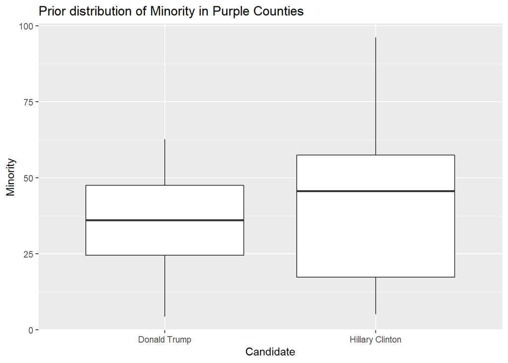

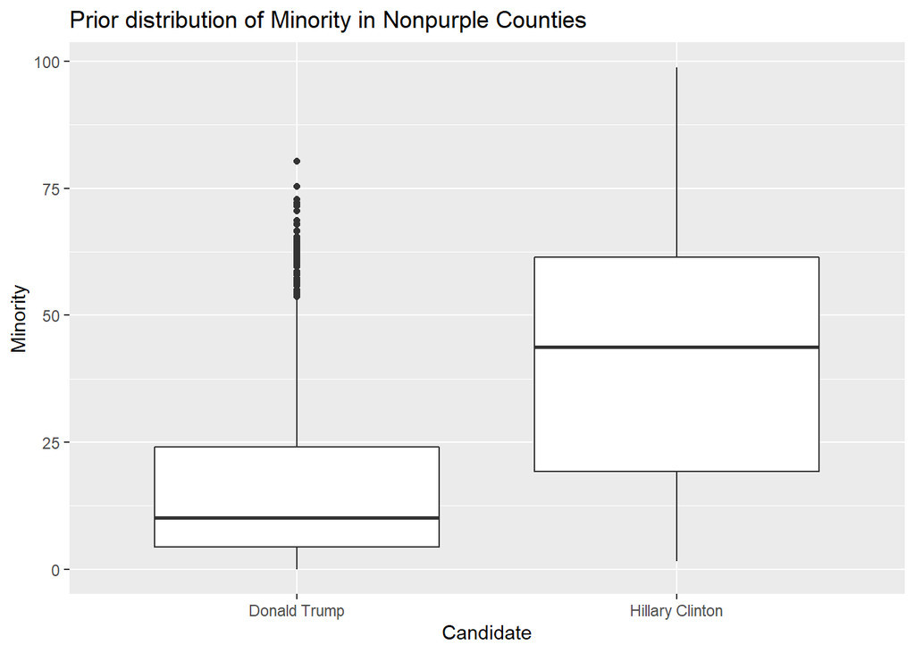

**Analysis** In a nonpurple county, if it went to Clinton then it had a larger proportion of minorities than if it went to Trump. In a purple county, if it went to Clinton then there is more variance in minorities if it went to Clinton, but the interquartile measurements for both candidates are more similar, with a tighter range for Trump than Clinton.

# Scatterplots

We now turn to construction of scatterplots. Points represent counties. They are colored according to winning candidate and sized according to total votes cast in the county.

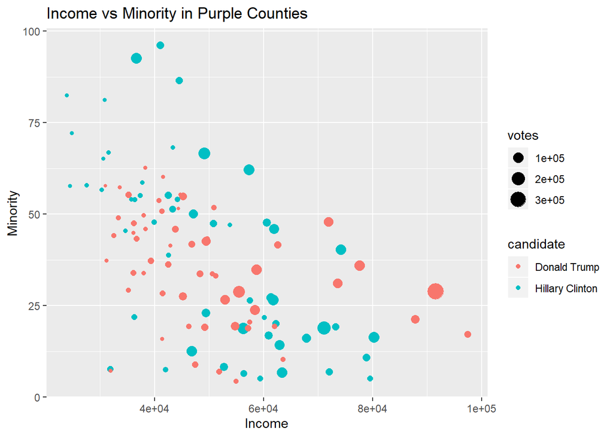

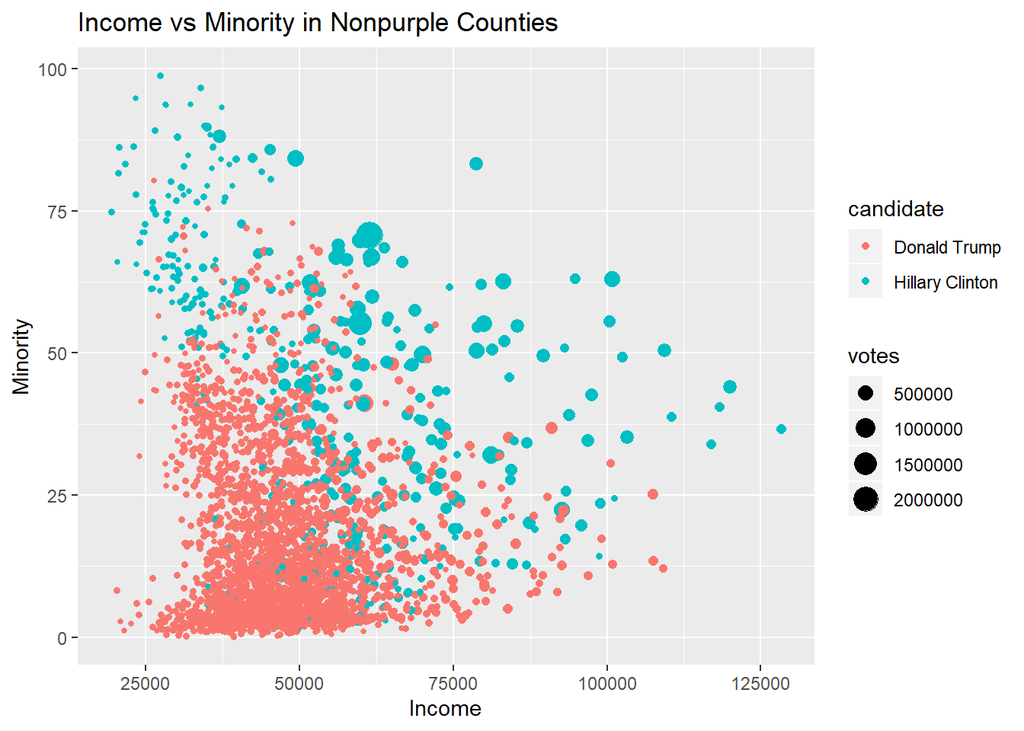

**Analysis**

In the nonpurple counties, there is a visible separation: counties with both low income and low minorities vote for Trump while higher income or higher minorities vote for Clinton.

This separation is not visibe in the purple counties.

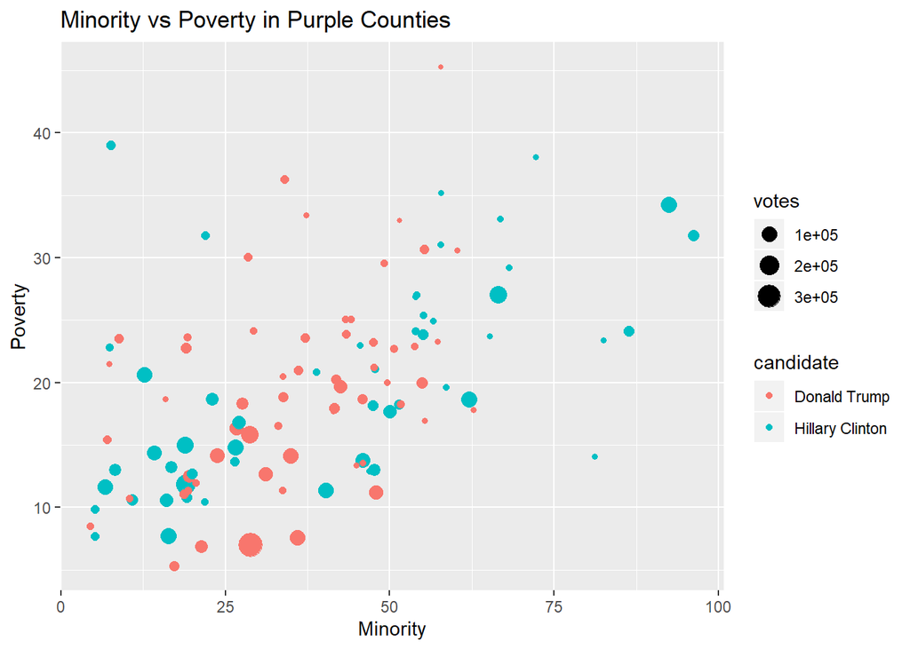

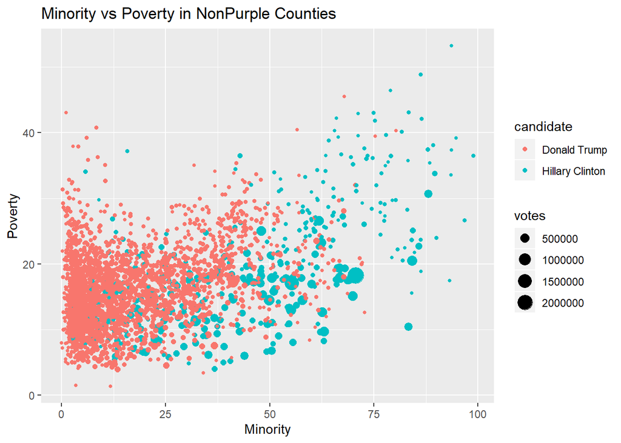

**Analysis** We see a separation in the nonpurple counties, lower in minorities vote for Trump and higher in minorities vote for Clinton, independent of poverty. This separation is not visible in the purple counties.

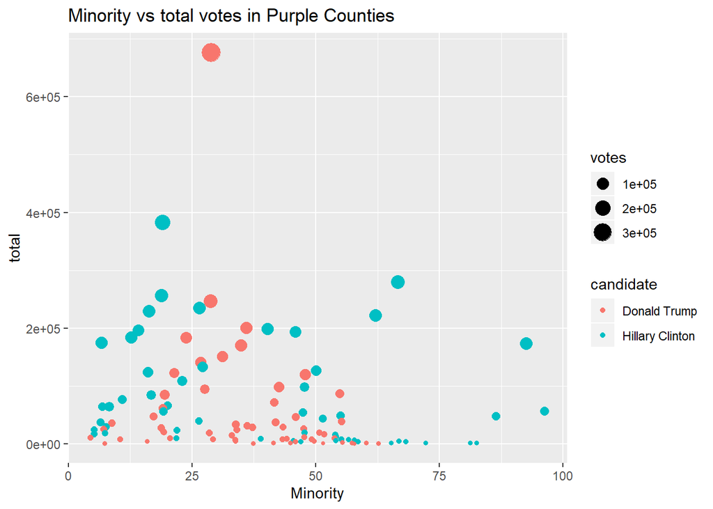

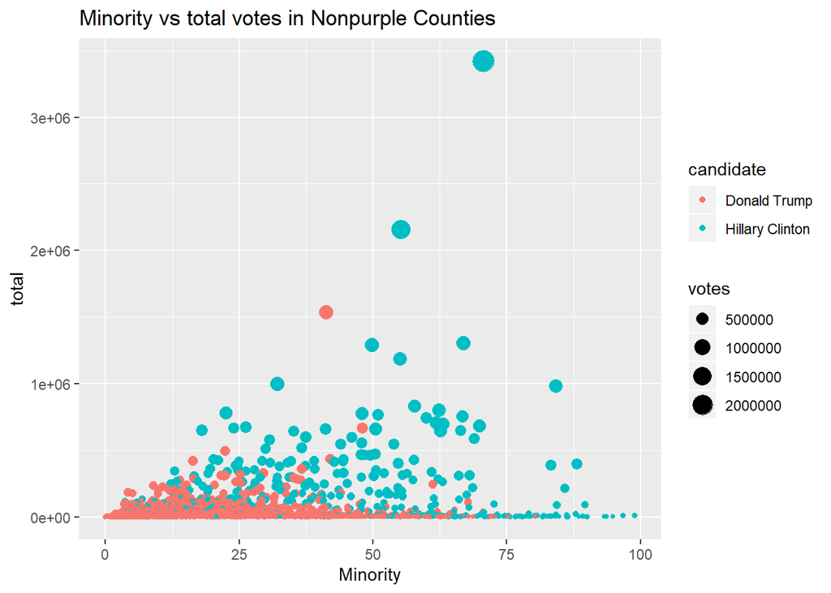

**Analysis** We see in the nonpurple counties that lower minority and lower population goes to Trump while increasing population and minorities goes to Clinton.

In the purple counties we can see a hint of a pattern. Minority between 20 and 50 tend toward Trump with the others tending to Clinton.

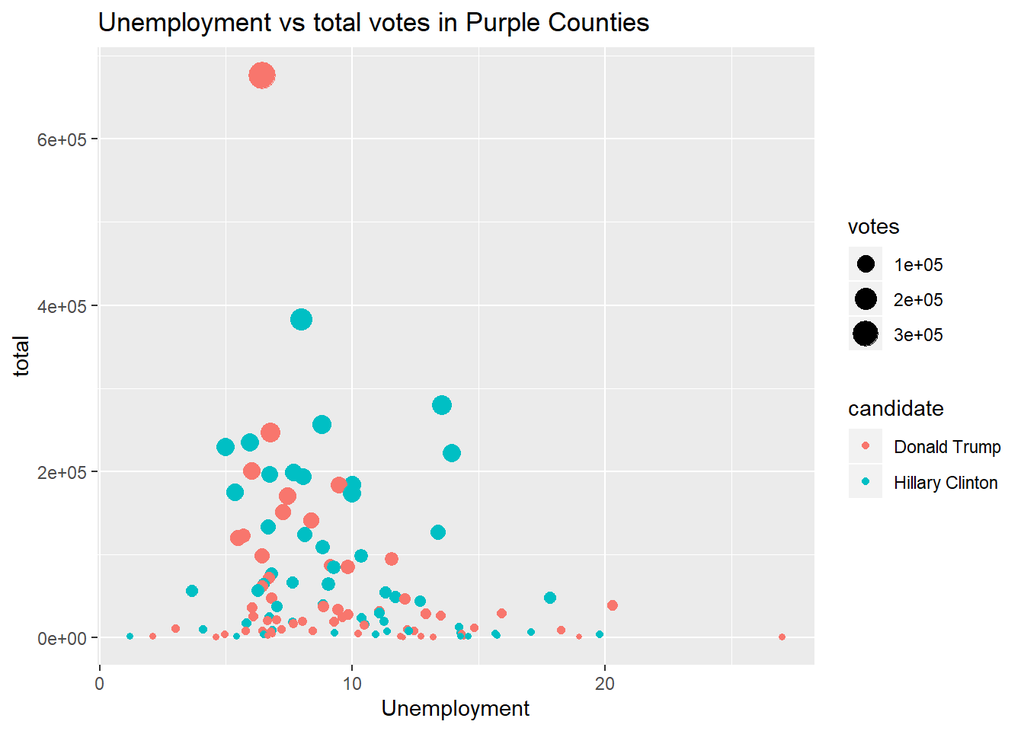

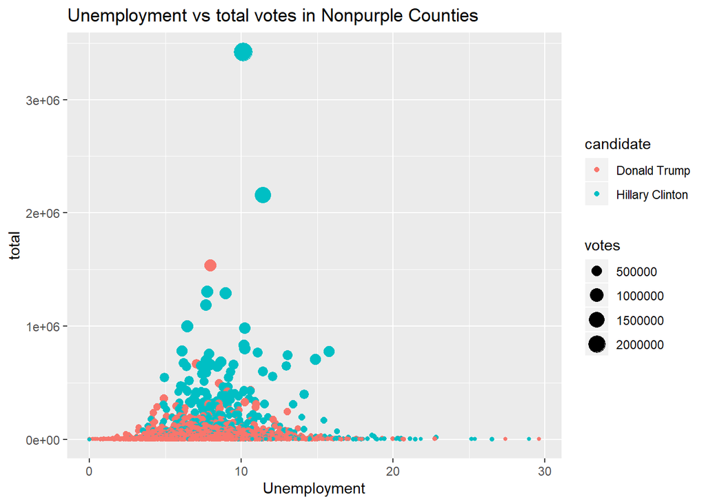

**Analysis**

In the nonpurple counties, low total votes tends to Trump, except more unemployment goes to Clinton. As total votes increase the county is more likely to go to Clinton.